# 지도학습2

## 1. 의사 결정 나무

### 1.1 의사결정나무 모형(Decision Tree)

1. 특정 항목에 대한 의사결정규칙을 나무 형태로 분류해 나가는 분석 기법을 말한다.
2. 조건문 형식을 가지는 것으로서 조건에 맞는지 여부에 따라 가지를 반복 분할하면서 모델을 만든다.
3. 분류조건에 명료할수록 유용하며, 전문가 프로그램에서 많이 사용되었다.
4. 결과를 해석하고 이해하기 쉽다.
- 구조 : 뿌리마다, 부모마디, 자식마디, 끝마디

### 1.2 의사결정나무 모형의 학습 방법

1. 데이터 집합을 적절한 분할 기준 또는 분할 테스트에 따라 나누는 과정이다.
2. 순환 분할 방식으로서 더이상 순수도를 높일 수 없거나, 말단 노드에 포함된 개체 수가 사전에 정한 최솟값에 도달하였거나, 노드의 깊이가 사전에 정해놓은 한계에 이를 때까지 재귀적으로 분할이 반복된다.
3. 이를 하향식 결정트리 귀납법이라고 한다.
4. 가지치기의 기준은 순수도(purity) 를 가장 높여줄 수 있는 변수를 먼저 선택해 진행한다.
5. 순수도를 측정하는 지니척도, 정보 이익이 많이 사용된다.

*### 지니척도*

- 두 번을 복원추출 했을 때, 동일범주 개체가 선택될 확률이다.
- 지니 척도는 순수도가 높을수록 1에, 균등할수록 0.5에 가까워진다.

*### 정보이익*

- 엔트로피의 개념을 사용.
- 먄약 두 범주의 확률이 모두 0.5 이면 엔트로피는 1이 된다.
- 만약 한 범주만 있는 완전히 순수한 상태이면 엔트로피는 0이 된다.
- 정보이익은 분리 전과 후의 엔트로피 차이를 계산해 얻는다.
- 비교 대상인 두 개 변수의 정보이익을 구하여 더 큰 쪽을 분리 기준으로 삼는다.

### 1.3 의사결정나무 실습 !

#### 1.3.1 데이터 준비

```r
autoparts <- read.csv("autoparts.csv", header=T)
autoparts1 <- autoparts[autoparts$prod_no=='90784-76001', c(2:11)]
autoparts2 <- autoparts1[autoparts1$c_thickness<1000,]
autoparts2$y_faulty <-ifelse((autoparts2$c_thickness<20)|(autoparts2$c_thickness>32),1,0)

t_index <- sample(1:nrow(autoparts2), size=nrow(autoparts2)*0.7)
train <- autoparts2[t_index,]
test <- autoparts2[-t_index,]

nrow(train); nrow(test);
```

```
## [1] 15236
```

```
## [1] 6531
```

#### 1.3.2 모델 생성

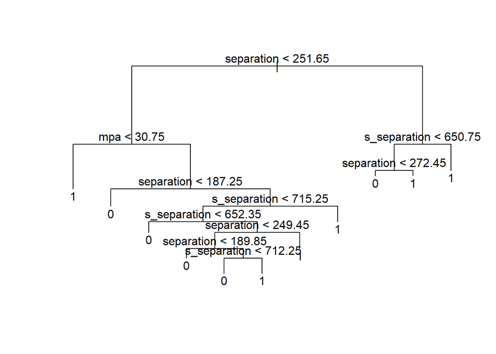

```r
#install.packages("tree")
library(tree)
m <- tree(factor(y_faulty) ~ fix_time + a_speed + b_speed + separation + s_separation + rate_terms + mpa + load_time
          + highpressure_time, data=train)
plot(m)
text(m)
```

#### 1.3.3 가지 치기

- 어느 정도 가지를 가지면 잘못된 분석이 줄어지는지에 대한 감각을 가질 수 있다.
- 가지가 9 정도가 되면 잘못된 분석이 매우 줄어든다.
- 가지가 3 정도만 되어도 잘못된 분석이 많이 떨어지는 것을 알 수 있다.
- 가지가 많을수록 정답률은 높아지나, 모델은 복잡해진다.

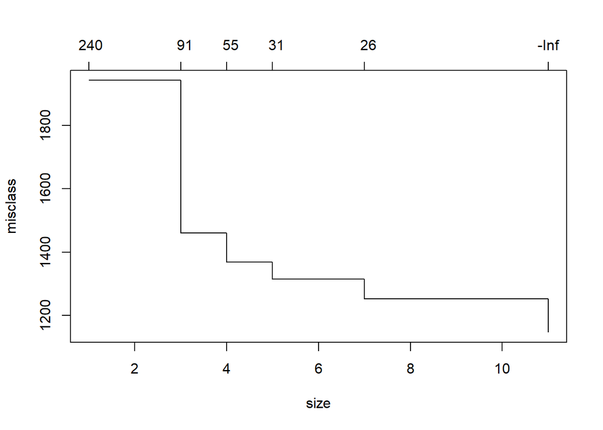

```r
prune.m <- prune.tree(m, method="misclass") # 잘못된 분류를 기준으로 가지치기한다.
plot(prune.m)
```

- 가지가 9 개일 때 여전히 복잡하므로 가지가 3개인 것으로 모델을 만들도록 한다.

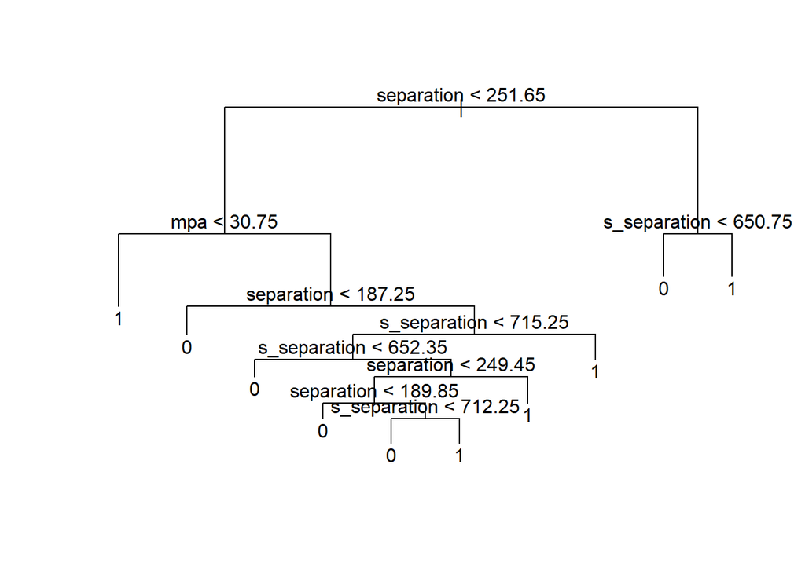

```r
prune.m <- prune.tree(m, best=9)
plot(prune.m)
text(prune.m)
```

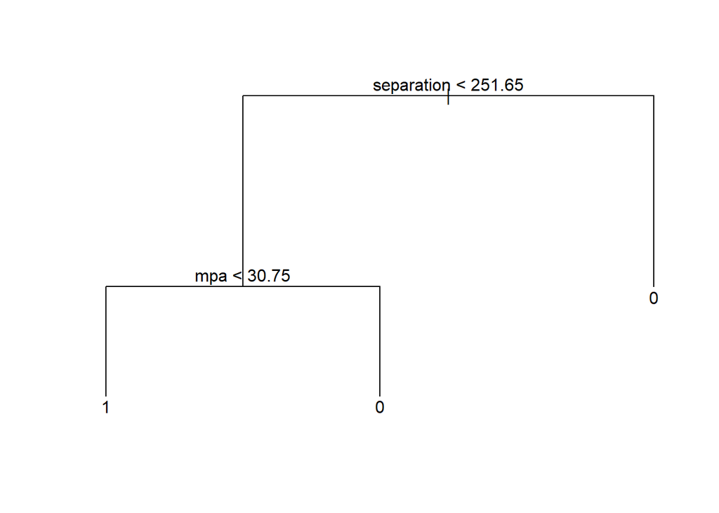

```r
prune.m <- prune.tree(m, best=3)
plot(prune.m)
text(prune.m)
```

#### 1.3.4 검증데이터 예측하기

```r
yhat_test <- predict(prune.m, test, type="class")
table <- table(real=test$y_faulty, predict=yhat_test)
table
```

```
##     predict
## real    0    1
##    0 5536   96
##    1  732  167
```

```r
(table[1,1] + table[2,2]) / sum(table)
```

```
## [1] 0.87322
```

```r
cat("약 ",(table[1,1] + table[2,2]) / sum(table) ,"%의 데이터를 올바르게 분류한다.")
```

```
## 약  0.87322 %의 데이터를 올바르게 분류한다.
```

#### 1.3.5 ROC, AUC

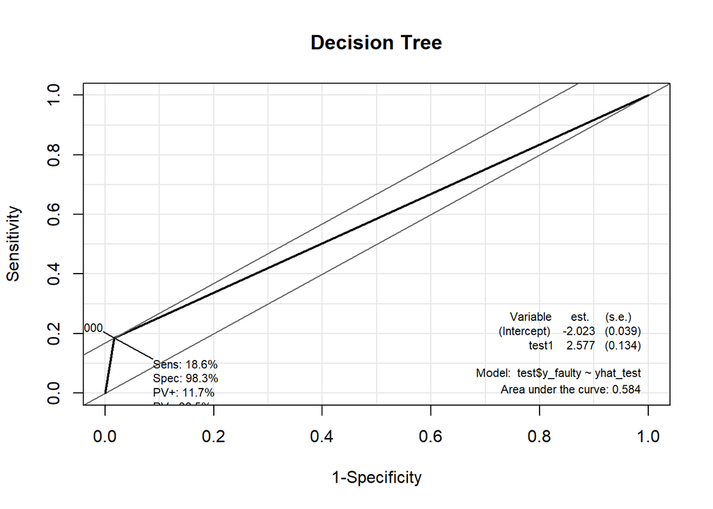

```r
library(Epi)
ROC(test = yhat_test, stat=test$y_faulty, plot="ROC", AUC=T, main="Decision Tree")
```

#### 1.3.6 새로운 데이터 예측

```r
new.data <- test
pred <- predict(prune.m, new.data, type="class")
```

### 1.4 다항 종속변수에 대하여 의사결정나무 모형 만들기

#### 1.4.1 데이터 준비

```r
autoparts2$g_class <- as.factor(ifelse(autoparts2$c_thickness<20,1,ifelse(autoparts2$c_thickness<32,2,3)))
t_index<-sample(1:nrow(autoparts2), size=nrow(autoparts2)*0.7)
train <- autoparts2[t_index,]
test <- autoparts2[-t_index,]
```

#### 1.4.2 모델 만들기

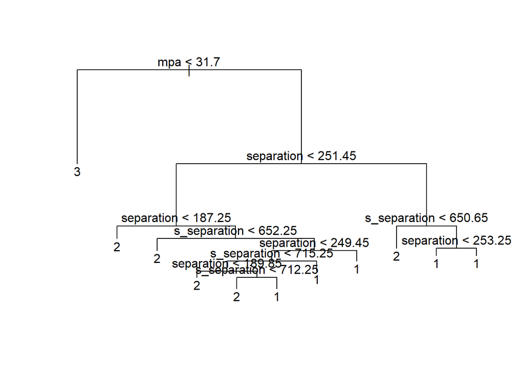

```r
m <- tree(g_class ~ fix_time+a_speed+b_speed+separation+s_separation+rate_terms+mpa+load_time+highpressure_time , data=train)
plot(m)
text(m)
```

#### 1.4.3 검증데이터 예측하기

```r
yhat_test <- predict(m, test, type="class")
table <- table(real= test$g_class, predict=yhat_test)
(table[1,1] + table[2,2]) / sum(table)
```

```
## [1] 0.8825601
```

### 1.5 연속형 종속변수에 대하여 의사결정나무 모형 만들기

- 다만 predict 부분에서 type=“class” 옵션을 사용하지 않는다.

#### 1.5.1 모델 생성

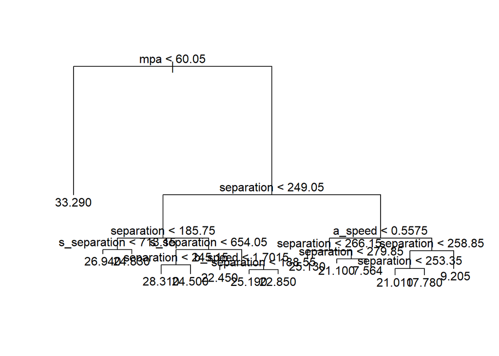

```r
m <-tree(c_thickness ~ fix_time+a_speed+b_speed+separation+s_separation+rate_terms+mpa+load_time+highpressure_time, data=train)
plot(m)
text(m)
```

#### 1.5.2 검증데이터 예측하기

```r
yhat_test <- predict(m, test)
head(yhat_test)
```

```
##        5        9       10       14       16       19
## 22.85273 22.85273 22.45092 22.45092 33.29391 22.45092
```

```r
head(test$c_thickness)
```

```
## [1] 24.5 22.2 19.0 17.9 36.7 25.4
```

#### 1.5.3 새로운 데이터 예측

```r
new.data <- test
yhat_test <- predict(m, test)
table(real = test$c_thickness, predict = yhat_test)
```

[output not shown]

[output cut: 1189 more lines]

[output not shown]

## 2. K-NN (최근접 이웃 분류)

- 새로운 점이 주어지면 그 점으로부터 가장 가까운점 K개를 이용하여 분류하는 머신러닝 기법이다.
- 즉, 근처 K 개의 점이 속한 분류를 보고 많이 속한 분류를 따라 분류를 한다.

### 2.1 적정 K의 선정

- 너무 작은 k 를 선정하면 주변 소수의 데이터에 너무 큰 영향을 받는다.
- 너무 큰 k를 선정하면 관련이 없는 먼 곳의 데이터 까지 분류에 영향을 끼치고, 정작 중요한 주변의 데이터 영향력은 작아진다.(과대적합)
- Cross Validation(교차검증)을 통해 오분류율이 낮은 K를 선정한다.
- K 값은 일반적으로 홀수를 취한다.

### 2.2 K-NN Regression

- 범주형은 물론, 연속형 데이터의 경우에도 K-NN 기법을 사용할 수 있다.
- 주변 K 개 데이터 값의 평균을 예측값으로 사용한다.
- 연속형 데이터에 대한 K-NN을 K-NN Regression 이라고 한다.

### 2.3 K-NN 실습

**1. 데이터 준비**

```r
autoparts <- read.csv("autoparts.csv", header=T)
autoparts1 <- autoparts[autoparts$prod_no=='90784-76001', c(2:11)]
autoparts2 <- autoparts1[autoparts1$c_thickness<1000,]
autoparts2$y_faulty <-ifelse((autoparts2$c_thickness<20)|(autoparts2$c_thickness>32),1,0)

t_index <- sample(1:nrow(autoparts2), size = nrow(autoparts2)*0.7)
train <- autoparts2[t_index,]
test <- autoparts2[-t_index,]
```

**2. Argument 준비**

```r
# 훈련데이터 행렬과 종속변수
xmat.train <- as.matrix(train[1:9])
y_faulty.train <- train$y_faulty

#검증데이터 행렬
xmat.test <- as.matrix(test[1:9])
head(xmat.test)
```

```
##    fix_time a_speed b_speed separation s_separation rate_terms  mpa
## 1      85.5   0.611   1.715      242.0        657.6         95 78.2
## 7      86.5   0.606   1.701      243.1        656.9         95 78.2
## 10     86.0   0.608   1.696      248.0        657.3         95 77.5
## 12     86.5   0.606   1.692      243.8        657.4         95 77.8
## 13     86.8   0.606   1.688      246.4        657.4         95 77.7
## 14     85.2   0.606   1.682      249.0        657.4         95 76.8
##    load_time highpressure_time
## 1       18.1                58
## 7       18.1                55
## 10      18.1                60
## 12      18.1                51
## 13      18.0                80
## 14      18.0                72
```

**3. 예측값 생성**

```r
library(class)
yhat_test <- knn(xmat.train, xmat.test, as.factor(y_faulty.train), k=3)

table <- table(real=test$y_faulty, predict=yhat_test)
table
```

```
##     predict
## real    0    1
##    0 5546  116
##    1  192  677
```

```r
(table[1,1] + table[2,2]) / sum(table)
```

```
## [1] 0.9528403
```

**4. 최적값 k 찾기** - 그래프를 보고 error가 가장 낮은 k를 활용하여 재수행할 수 있다. !

```r
library(e1071)
tune.out <- tune.knn(x=xmat.train, y=as.factor(y_faulty.train), k=1:10)
tune.out
```

```
##
## Parameter tuning of 'knn.wrapper':
##
## - sampling method: 10-fold cross validation
##
## - best parameters:
##  k
##  5
##
## - best performance: 0.04620629
```

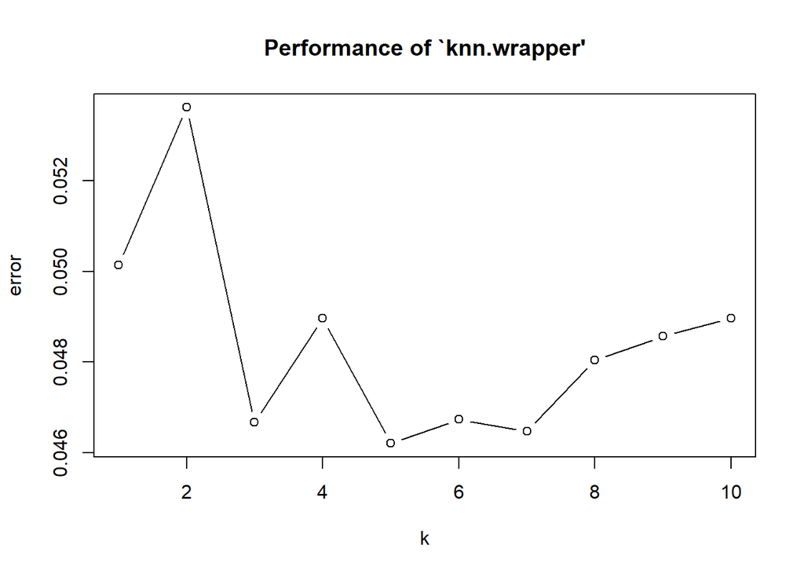

```r
plot(tune.out)
```

**5. knn 재수행**

```r
# 최적의 k로 knn재수행
yhat_test <- knn(xmat.train, xmat.test, y_faulty.train, k=5)
table <- table(real= test$y_faulty, predict=yhat_test)
table
```

```
##     predict
## real    0    1
##    0 5551  111
##    1  203  666
```

```r
(table[1,1] + table[2,2]) / sum(table)
```

```
## [1] 0.9519216
```

**6. ROC, AUC**

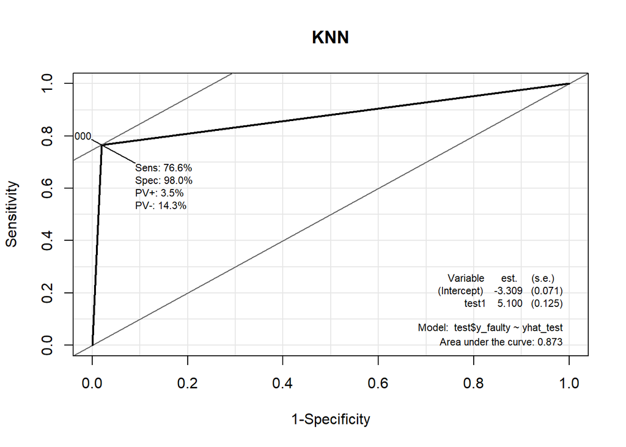

```r
library(Epi)
ROC(test = yhat_test , stat= test$y_faulty, plot="ROC", AUC=T, main="KNN")
```

### 2.4 종속변수가 다항인 경우의 K-NN

**1. 데이터 준비**

```r
autoparts <- read.csv("autoparts.csv", header=T)
autoparts1 <- autoparts[autoparts$prod_no=='90784-76001', c(2:11)]
autoparts2 <- autoparts1[autoparts1$c_thickness<1000,]
autoparts2$g_class <-ifelse(autoparts2$c_thickness<20,1,ifelse(autoparts2$c_thickness<32,2,3))

t_index <- sample(1:nrow(autoparts2), size=nrow(autoparts2)*0.7)
train <- autoparts2[t_index,]
test <- autoparts2[-t_index,]
```

**2. 예측값 생성**

```r
xmat.train <- as.matrix(train[1:9])
g_class.train <- train$g_class
xmat.test <- as.matrix(test[1:9])

library(class)
yhat_test <- knn(xmat.train, xmat.test, g_class.train, k=3)
table <- table(real= test$g_class, predict=yhat_test)
(table[1,1]+table[2,2]+table[3,3])/sum(table)
```

[output not shown]

### 2.5 종속변수가 연속형인 경우의 K-NN

- 데이터 생성하고 훈련데이터, 검증데이터 만들기.

```r
autoparts <- read.csv("autoparts.csv", header=T)
auotparts1 <- autoparts[autoparts$prod_no=="90784-76001",c(2:11)]
autoparts2 <- autoparts[autoparts1$c_thickness<1000,]

t_index <- sample(1: nrow(autoparts2), size=nrow(autoparts2)*0.7)
train <- autoparts2[t_index,]
test <- autoparts2[-t_index,]
```

- 예측값 생성 ( 패키지 “FNN”의 knn.reg 함수 활용)

```r
xmat.train <- as.matrix(train[1:9])
c_thickness.train <- train$c_thickness
xmat.test <- as.matrix(test[1:9])

#install.packages("FNN")
library(FNN)
# yhat_test <- knn.reg(xmat.train, xmat.test, c_thickness.train, k=3) 에러가 남..
#mse <- mean( (yhat_test$pred - test$c_thickness)^2 )
```

## 3. 인공신경망

## 4. [R실습] 예제 데이터 실습